# Predicting Spotify Song Genre

Dhwani & Shrey

4/3/2020

### Introduction

The data used in this project is from Spotify which is also available in spotify package. The infromation on the dataset can be found [here](https://github.com/rfordatascience/tidytuesday/blob/master/data/2020/2020-01-21/readme.md).The dataset here consists of various audio features of a song like acousticness, liveness, speechiness, instrumentalness, energy, loudness, danceability, valence (positiveness), duration, tempo, key, and mode along with popularity of the song.

We intend to predict popularity of the song based on its avaialable audio features using machine learning technique by building a classification model.

This analysis could help various musicians and artists to get a broad understanding on what kind of audio features should they be including in their song to make it popular. Not only artist and musicians the model will also help various online song streaming services to decided what kind of songs to add in their database in order to have more popular songs in their bucket

### Packages Required

Following packages are required to import, analyze, view and manipulate data:

```r
library(readr)
library(tidyverse)
library(knitr)
library(dplyr)
library(psych)
```

```r
library(ggplot2)
library(cowplot)
library(psych)
library(ROCR)
library(rpart)
library(rpart.plot)
```

Following packages are used to run classification models:

```r
library(rpart)
library(rpart.plot)
```

### Data Preparation

The dataset used in this analysis can be found [here](https://raw.githubusercontent.com/rfordatascience/tidytuesday/master/data/2020/2020-01-21/spotify_songs.csv). Witht the below code we have performed two prime activities of reading and previewing data

```r
spotify=read.csv('spotify_songs.csv', stringsAsFactors = FALSE)
head(spotify)
```

```
##                 track_id                                            track_name
## 1 6f807x0ima9a1j3VPbc7VN I Don't Care (with Justin Bieber) - Loud Luxury Remix
## 2 0r7CVbZTWZgbTCYdfa2P31                       Memories - Dillon Francis Remix
## 3 1z1Hg7Vb0AhHDiEmnDE79l                       All the Time - Don Diablo Remix
## 4 75FpbthrwQmzHlBJLuGdC7                     Call You Mine - Keanu Silva Remix
## 5 1e8PAfcKUYoKkxPhrHqw4x               Someone You Loved - Future Humans Remix
## 6 7fvUMiyapMsRRxr07cU8Ef     Beautiful People (feat. Khalid) - Jack Wins Remix
##       track_artist track_popularity         track_album_id
## 1       Ed Sheeran               66 2oCs0DGTsRO98Gh5ZSl2Cx
## 2         Maroon 5               67 63rPSO264uRjW1X5E6cWv6
## 3     Zara Larsson               70 1HoSmj2eLcsrR0vE9gThr4
## 4 The Chainsmokers               60 1nqYsOef1yKKuGOVchbsk6
## 5    Lewis Capaldi               69 7m7vv9wlQ4i0LFuJiE2zsQ
## 6       Ed Sheeran               67 2yiy9cd2QktrNvWC2EUi0k
##                                        track_album_name
```

[output cut: 27 more lines]

In this section we are trying to explain each auido features which we will be using in our further model building and analysis

```r
var_desc<-c("Song unique ID","Song Name","Song Artist","Song Popularity (0-100) where higher is better","Album unique ID","Song album name","Date when album released","Name of playlist","Playlist ID","Playlist genre","Playlist subgenre","Danceability describes how suitable a track is for dancing based on a combination of musical elements including tempo, rhythm stability, beat strength, and overall regularity. A value of 0.0 is least danceable and 1.0 is most danceable.","Energy is a measure from 0.0 to 1.0 and represents a perceptual measure of intensity and activity. Typically, energetic tracks feel fast, loud, and noisy. For example, death metal has high energy, while a Bach prelude scores low on the scale. Perceptual features contributing to this attribute include dynamic range, perceived loudness, timbre, onset rate, and general entropy.","The estimated overall key of the track. Integers map to pitches using standard Pitch Class notation . E.g. 0 = C, 1 = C?/D?, 2 = D, and so on. If no key was detected, the value is -1.","The overall loudness of a track in decibels (dB). Loudness values are averaged across the entire track and are useful for comparing relative loudness of tracks. Loudness is the quality of a sound that is the primary psychological correlate of physical strength (amplitude). Values typical range between -60 and 0 db.","Mode indicates the modality (major or minor) of a track, the type of scale from which its melodic content is derived. Major is represented by 1 and minor is 0.","Speechiness detects the presence of spoken words in a track. The more exclusively speech-like the recording (e.g. talk show, audio book, poetry), the closer to 1.0 the attribute value. Values above 0.66 describe tracks that are probably made entirely of spoken words. Values between 0.33 and 0.66 describe tracks that may contain both music and speech, either in sections or layered, including such cases as rap music. Values below 0.33 most likely represent music and other non-speech-like tracks.","A confidence measure from 0.0 to 1.0 of whether the track is acoustic. 1.0 represents high confidence the track is acoustic.","Predicts whether a track contains no vocals. “Ooh” and “aah” sounds are treated as instrumental in this context. Rap or spoken word tracks are clearly “vocal”. The closer the instrumentalness value is to 1.0, the greater likelihood the track contains no vocal content. Values above 0.5 are intended to represent instrumental tracks, but confidence is higher as the value approaches 1.0.","Detects the presence of an audience in the recording. Higher liveness values represent an increased probability that the track was performed live. A value above 0.8 provides strong likelihood that the track is live.","A measure from 0.0 to 1.0 describing the musical positiveness conveyed by a track. Tracks with high valence sound more positive (e.g. happy, cheerful, euphoric), while tracks with low valence sound more negative (e.g. sad, depressed, angry).","The overall estimated tempo of a track in beats per minute (BPM). In musical terminology, tempo is the speed or pace of a given piece and derives directly from the average beat duration.","Duration of song in milliseconds")
spotify.type<-lapply(spotify,class)
var_names<-colnames(spotify)
data.desc<-as_tibble(cbind(var_names,spotify.type,var_desc))
kable(data.desc)
```

| var_names | spotify.type | var_desc |
| --- | --- | --- |
| track_id | character | Song unique ID |
| track_name | character | Song Name |
| track_artist | character | Song Artist |
| track_popularity | integer | Song Popularity (0-100) where higher is better |
| track_album_id | character | Album unique ID |
| track_album_name | character | Song album name |
| track_album_release_date | character | Date when album released |
| playlist_name | character | Name of playlist |
| playlist_id | character | Playlist ID |
| playlist_genre | character | Playlist genre |
| playlist_subgenre | character | Playlist subgenre |
| danceability | numeric | Danceability describes how suitable a track is for dancing based on a combination of musical elements including tempo, rhythm stability, beat strength, and overall regularity. A value of 0.0 is least … |
| energy | numeric | Energy is a measure from 0.0 to 1.0 and represents a perceptual measure of intensity and activity. Typically, energetic tracks feel fast, loud, and noisy. For example, death metal has high energy, whi… |
| key | integer | The estimated overall key of the track. Integers map to pitches using standard Pitch Class notation . E.g. 0 = C, 1 = C?/D?, 2 = D, and so on. If no key was detected, the value is -1. |
| loudness | numeric | The overall loudness of a track in decibels (dB). Loudness values are averaged across the entire track and are useful for comparing relative loudness of tracks. Loudness is the quality of a sound that… |
| mode | integer | Mode indicates the modality (major or minor) of a track, the type of scale from which its melodic content is derived. Major is represented by 1 and minor is 0. |
| speechiness | numeric | Speechiness detects the presence of spoken words in a track. The more exclusively speech-like the recording (e.g. talk show, audio book, poetry), the closer to 1.0 the attribute value. Values above 0.… |
| acousticness | numeric | A confidence measure from 0.0 to 1.0 of whether the track is acoustic. 1.0 represents high confidence the track is acoustic. |
| instrumentalness | numeric | Predicts whether a track contains no vocals. “Ooh” and “aah” sounds are treated as instrumental in this context. Rap or spoken word tracks are clearly “vocal”. The closer the instrumentalness value is… |
| liveness | numeric | Detects the presence of an audience in the recording. Higher liveness values represent an increased probability that the track was performed live. A value above 0.8 provides strong likelihood that the… |
| valence | numeric | A measure from 0.0 to 1.0 describing the musical positiveness conveyed by a track. Tracks with high valence sound more positive (e.g. happy, cheerful, euphoric), while tracks with low valence sound mo… |
| tempo | numeric | The overall estimated tempo of a track in beats per minute (BPM). In musical terminology, tempo is the speed or pace of a given piece and derives directly from the average beat duration. |
| duration_ms | integer | Duration of song in milliseconds |

Here in this section we have added a new colum called tarck_year which is basically derived form the track_album_release_date. Apart from this we dont intend to drop any columns from our dataset as all of them are required and visualized in our further process.

```r
spotify<-spotify %>% mutate(track_year=substr(spotify$track_album_release_date, 1, 4))
spotify$track_year <- as.numeric(spotify$track_year)
head(spotify)
```

```
##                 track_id                                            track_name
## 1 6f807x0ima9a1j3VPbc7VN I Don't Care (with Justin Bieber) - Loud Luxury Remix
## 2 0r7CVbZTWZgbTCYdfa2P31                       Memories - Dillon Francis Remix
## 3 1z1Hg7Vb0AhHDiEmnDE79l                       All the Time - Don Diablo Remix
## 4 75FpbthrwQmzHlBJLuGdC7                     Call You Mine - Keanu Silva Remix
## 5 1e8PAfcKUYoKkxPhrHqw4x               Someone You Loved - Future Humans Remix
## 6 7fvUMiyapMsRRxr07cU8Ef     Beautiful People (feat. Khalid) - Jack Wins Remix
##       track_artist track_popularity         track_album_id
## 1       Ed Sheeran               66 2oCs0DGTsRO98Gh5ZSl2Cx
## 2         Maroon 5               67 63rPSO264uRjW1X5E6cWv6
## 3     Zara Larsson               70 1HoSmj2eLcsrR0vE9gThr4
## 4 The Chainsmokers               60 1nqYsOef1yKKuGOVchbsk6
## 5    Lewis Capaldi               69 7m7vv9wlQ4i0LFuJiE2zsQ
## 6       Ed Sheeran               67 2yiy9cd2QktrNvWC2EUi0k
##                                        track_album_name
```

[output cut: 27 more lines]

This peice of code allows us to see the the overall size of our dataset by providing information of number of rows and column

```r
dim(spotify)
```

```
## [1] 32833    24
```

Here in this peice we are trying to understand various types of variables and their classes by using str() function.

```r
str(spotify)
```

```
## 'data.frame':    32833 obs. of  24 variables:
##  $ track_id                : chr  "6f807x0ima9a1j3VPbc7VN" "0r7CVbZTWZgbTCYdfa2P31" "1z1Hg7Vb0AhHDiEmnDE79l" "75FpbthrwQmzHlBJLuGdC7" ...
##  $ track_name              : chr  "I Don't Care (with Justin Bieber) - Loud Luxury Remix" "Memories - Dillon Francis Remix" "All the Time - Don Diablo Remix" "Call You Mine - Keanu Silva Remix" ...
##  $ track_artist            : chr  "Ed Sheeran" "Maroon 5" "Zara Larsson" "The Chainsmokers" ...
##  $ track_popularity        : int  66 67 70 60 69 67 62 69 68 67 ...
##  $ track_album_id          : chr  "2oCs0DGTsRO98Gh5ZSl2Cx" "63rPSO264uRjW1X5E6cWv6" "1HoSmj2eLcsrR0vE9gThr4" "1nqYsOef1yKKuGOVchbsk6" ...
##  $ track_album_name        : chr  "I Don't Care (with Justin Bieber) [Loud Luxury Remix]" "Memories (Dillon Francis Remix)" "All the Time (Don Diablo Remix)" "Call You Mine - The Remixes" ...
##  $ track_album_release_date: chr  "2019-06-14" "2019-12-13" "2019-07-05" "2019-07-19" ...
##  $ playlist_name           : chr  "Pop Remix" "Pop Remix" "Pop Remix" "Pop Remix" ...
##  $ playlist_id             : chr  "37i9dQZF1DXcZDD7cfEKhW" "37i9dQZF1DXcZDD7cfEKhW" "37i9dQZF1DXcZDD7cfEKhW" "37i9dQZF1DXcZDD7cfEKhW" ...
##  $ playlist_genre          : chr  "pop" "pop" "pop" "pop" ...
##  $ playlist_subgenre       : chr  "dance pop" "dance pop" "dance pop" "dance pop" ...
##  $ danceability            : num  0.748 0.726 0.675 0.718 0.65 0.675 0.449 0.542 0.594 0.642 ...
##  $ energy                  : num  0.916 0.815 0.931 0.93 0.833 0.919 0.856 0.903 0.935 0.818 ...
##  $ key                     : int  6 11 1 7 1 8 5 4 8 2 ...
##  $ loudness                : num  -2.63 -4.97 -3.43 -3.78 -4.67 ...
##  $ mode                    : int  1 1 0 1 1 1 0 0 1 1 ...
##  $ speechiness             : num  0.0583 0.0373 0.0742 0.102 0.0359 0.127 0.0623 0.0434 0.0565 0.032 ...
##  $ acousticness            : num  0.102 0.0724 0.0794 0.0287 0.0803 0.0799 0.187 0.0335 0.0249 0.0567 ...
##  $ instrumentalness        : num  0.00 4.21e-03 2.33e-05 9.43e-06 0.00 0.00 0.00 4.83e-06 3.97e-06 0.00 ...
##  $ liveness                : num  0.0653 0.357 0.11 0.204 0.0833 0.143 0.176 0.111 0.637 0.0919 ...
##  $ valence                 : num  0.518 0.693 0.613 0.277 0.725 0.585 0.152 0.367 0.366 0.59 ...
##  $ tempo                   : num  122 100 124 122 124 ...
##  $ duration_ms             : int  194754 162600 176616 169093 189052 163049 187675 207619 193187 253040 ...
##  $ track_year              : num  2019 2019 2019 2019 2019 ...
```

In this part we have a quick look at the various columns and analyse the values within each of the column by calculating the min and max for numeric and integer type columns and length for character type column

```r
summary(spotify)
```

```
##    track_id          track_name        track_artist       track_popularity
##  Length:32833       Length:32833       Length:32833       Min.   :  0.00
##  Class :character   Class :character   Class :character   1st Qu.: 24.00
##  Mode  :character   Mode  :character   Mode  :character   Median : 45.00
##                                                           Mean   : 42.48
##                                                           3rd Qu.: 62.00
##                                                           Max.   :100.00
##  track_album_id     track_album_name   track_album_release_date
##  Length:32833       Length:32833       Length:32833
##  Class :character   Class :character   Class :character
##  Mode  :character   Mode  :character   Mode  :character
##
##
##
##  playlist_name      playlist_id        playlist_genre     playlist_subgenre
##  Length:32833       Length:32833       Length:32833       Length:32833
##  Class :character   Class :character   Class :character   Class :character
##  Mode  :character   Mode  :character   Mode  :character   Mode  :character
##
##
##
##   danceability        energy              key            loudness
##  Min.   :0.0000   Min.   :0.000175   Min.   : 0.000   Min.   :-46.448
##  1st Qu.:0.5630   1st Qu.:0.581000   1st Qu.: 2.000   1st Qu.: -8.171
##  Median :0.6720   Median :0.721000   Median : 6.000   Median : -6.166
##  Mean   :0.6548   Mean   :0.698619   Mean   : 5.374   Mean   : -6.720
##  3rd Qu.:0.7610   3rd Qu.:0.840000   3rd Qu.: 9.000   3rd Qu.: -4.645
##  Max.   :0.9830   Max.   :1.000000   Max.   :11.000   Max.   :  1.275
##       mode         speechiness      acousticness    instrumentalness
##  Min.   :0.0000   Min.   :0.0000   Min.   :0.0000   Min.   :0.0000000
##  1st Qu.:0.0000   1st Qu.:0.0410   1st Qu.:0.0151   1st Qu.:0.0000000
##  Median :1.0000   Median :0.0625   Median :0.0804   Median :0.0000161
##  Mean   :0.5657   Mean   :0.1071   Mean   :0.1753   Mean   :0.0847472
##  3rd Qu.:1.0000   3rd Qu.:0.1320   3rd Qu.:0.2550   3rd Qu.:0.0048300
##  Max.   :1.0000   Max.   :0.9180   Max.   :0.9940   Max.   :0.9940000
##     liveness         valence           tempo         duration_ms
##  Min.   :0.0000   Min.   :0.0000   Min.   :  0.00   Min.   :  4000
##  1st Qu.:0.0927   1st Qu.:0.3310   1st Qu.: 99.96   1st Qu.:187819
##  Median :0.1270   Median :0.5120   Median :121.98   Median :216000
##  Mean   :0.1902   Mean   :0.5106   Mean   :120.88   Mean   :225800
##  3rd Qu.:0.2480   3rd Qu.:0.6930   3rd Qu.:133.92   3rd Qu.:253585
##  Max.   :0.9960   Max.   :0.9910   Max.   :239.44   Max.   :517810
##    track_year
##  Min.   :1957
##  1st Qu.:2008
##  Median :2016
##  Mean   :2011
##  3rd Qu.:2019
##  Max.   :2020
```

From the below set of codes we have witnessed that there are no duplicate rows present in the dataset and 0.02% of missing values which we currently keep it as it is.

```r
# percentage of missing data in each columns
round(colSums(is.na(spotify)*100/nrow(spotify)),2)
```

```
##                 track_id               track_name             track_artist
##                     0.00                     0.02                     0.02
##         track_popularity           track_album_id         track_album_name
##                     0.00                     0.00                     0.02
## track_album_release_date            playlist_name              playlist_id
##                     0.00                     0.00                     0.00
##           playlist_genre        playlist_subgenre             danceability
##                     0.00                     0.00                     0.00
##                   energy                      key                 loudness
##                     0.00                     0.00                     0.00
##                     mode              speechiness             acousticness
##                     0.00                     0.00                     0.00
##         instrumentalness                 liveness                  valence
##                     0.00                     0.00                     0.00
##                    tempo              duration_ms               track_year
##                     0.00                     0.00                     0.00
```

```r
#checking for duplicate rows
count(spotify[duplicated(spotify[1:23]),])
```

```
## # A tibble: 1 x 1
##       n
##   <int>
## 1     0
```

From all the below codes we are making a subset of our data by selecting columns which are required for our classification model

```r
#counting the number of songs by genre
spotify %>% count(playlist_genre)
```

```
## # A tibble: 6 x 2
##   playlist_genre     n
##   <chr>          <int>
## 1 edm             6043
## 2 latin           5155
## 3 pop             5507
## 4 r&b             5431
## 5 rap             5746
## 6 rock            4951
```

```r
#counting the number of songs by their popularity ranking.
spotify %>% count(track_popularity)
```

```
## # A tibble: 101 x 2
##    track_popularity     n
##               <int> <int>
##  1                0  2703
##  2                1   575
##  3                2   387
##  4                3   321
##  5                4   240
##  6                5   240
##  7                6   192
##  8                7   189
##  9                8   201
## 10                9   195
## # ... with 91 more rows
```

A large number of songs are on the 0th position compared to other positions.

```r
numeric_features <-as.data.frame(spotify[,c(4,12:24)])
```

```r
summary(numeric_features)
```

```
##  track_popularity  danceability        energy              key
##  Min.   :  0.00   Min.   :0.0000   Min.   :0.000175   Min.   : 0.000
##  1st Qu.: 24.00   1st Qu.:0.5630   1st Qu.:0.581000   1st Qu.: 2.000
##  Median : 45.00   Median :0.6720   Median :0.721000   Median : 6.000
##  Mean   : 42.48   Mean   :0.6548   Mean   :0.698619   Mean   : 5.374
##  3rd Qu.: 62.00   3rd Qu.:0.7610   3rd Qu.:0.840000   3rd Qu.: 9.000
##  Max.   :100.00   Max.   :0.9830   Max.   :1.000000   Max.   :11.000
##     loudness            mode         speechiness      acousticness
##  Min.   :-46.448   Min.   :0.0000   Min.   :0.0000   Min.   :0.0000
##  1st Qu.: -8.171   1st Qu.:0.0000   1st Qu.:0.0410   1st Qu.:0.0151
##  Median : -6.166   Median :1.0000   Median :0.0625   Median :0.0804
##  Mean   : -6.720   Mean   :0.5657   Mean   :0.1071   Mean   :0.1753
##  3rd Qu.: -4.645   3rd Qu.:1.0000   3rd Qu.:0.1320   3rd Qu.:0.2550
##  Max.   :  1.275   Max.   :1.0000   Max.   :0.9180   Max.   :0.9940
##  instrumentalness       liveness         valence           tempo
##  Min.   :0.0000000   Min.   :0.0000   Min.   :0.0000   Min.   :  0.00
##  1st Qu.:0.0000000   1st Qu.:0.0927   1st Qu.:0.3310   1st Qu.: 99.96
##  Median :0.0000161   Median :0.1270   Median :0.5120   Median :121.98
##  Mean   :0.0847472   Mean   :0.1902   Mean   :0.5106   Mean   :120.88
##  3rd Qu.:0.0048300   3rd Qu.:0.2480   3rd Qu.:0.6930   3rd Qu.:133.92
##  Max.   :0.9940000   Max.   :0.9960   Max.   :0.9910   Max.   :239.44
##   duration_ms       track_year
##  Min.   :  4000   Min.   :1957
##  1st Qu.:187819   1st Qu.:2008
##  Median :216000   Median :2016
##  Mean   :225800   Mean   :2011
##  3rd Qu.:253585   3rd Qu.:2019
##  Max.   :517810   Max.   :2020
```

### Exploratory Data Analysis

Basically we want to build a model that could predict popularity of a song inorder to predict that accurately its importact to closely study all the audio features and we have done that by below visualizating each feature individually

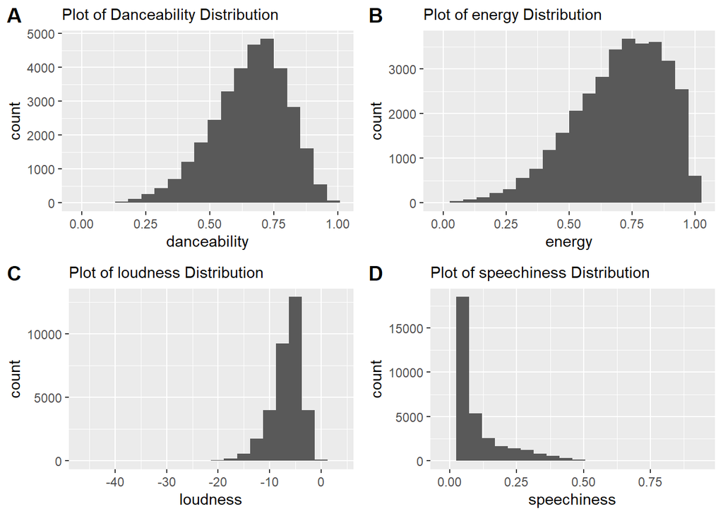

```r
#plotting the distribution of years of tracks
dance1<-ggplot(spotify, aes(danceability)) +
  geom_histogram(bins = 20) +
  ggtitle("Plot of Danceability Distribution") +
  theme(plot.title = element_text(size = 11))

#plotting the distribution of energy of tracks
energy2<-ggplot(spotify, aes(energy)) +
  geom_histogram(bins = 20) +
  ggtitle("Plot of energy Distribution") +
  theme(plot.title = element_text(size = 11))

#ploting the distribution of loudness of tracks
loud3<-ggplot(spotify, aes(loudness)) +
  geom_histogram(bins = 20) +
  ggtitle("Plot of loudness Distribution") +
  theme(plot.title = element_text(size = 11))

#plotting the speechness of years of tracks
speech4 <- ggplot(spotify, aes(speechiness)) +
  geom_histogram(bins = 20) +
  ggtitle("Plot of speechiness Distribution") +
  theme(plot.title = element_text(size = 11))



plot_grid(dance1, energy2, loud3,speech4, labels = "AUTO")
```

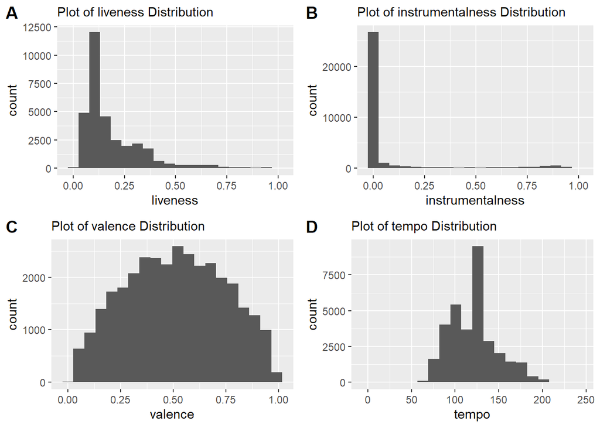

```r
#plotting the liveness of years of tracks
live5<-ggplot(spotify, aes(liveness)) +
  geom_histogram(bins = 20) +
  ggtitle("Plot of liveness Distribution") +
  theme(plot.title = element_text(size = 11))

#plotting the instrumentalness of years of tracks
instrument6<-ggplot(spotify, aes(instrumentalness)) +
  geom_histogram(bins = 20) +
  ggtitle("Plot of instrumentalness Distribution") +
  theme(plot.title = element_text(size = 11))

#plotting the valence(positivity) of years of tracks
valence7<-ggplot(spotify, aes(valence)) +
  geom_histogram(bins = 20) +
  ggtitle("Plot of valence Distribution") +
  theme(plot.title = element_text(size = 11))

#plotting the tempo of years of tracks
tempo8<-ggplot(spotify, aes(tempo)) +
  geom_histogram(bins = 20) +
  ggtitle("Plot of tempo Distribution") +
  theme(plot.title = element_text(size = 11))

plot_grid(live5, instrument6, valence7,tempo8, labels = "AUTO")
```

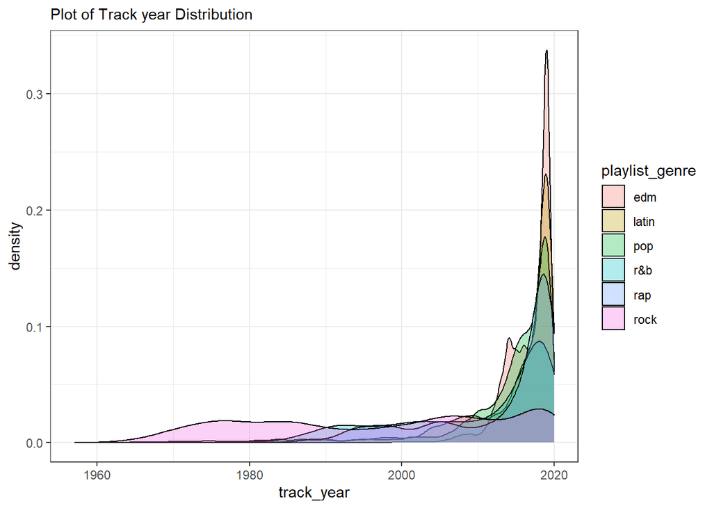

```r
#plotting the distribution of years of tracks
ggplot(spotify, aes(track_year, fill=playlist_genre)) +
  geom_density(alpha = 0.3) + theme_bw() +
  ggtitle("Plot of Track year Distribution") +
  theme(plot.title = element_text(size = 11))
```

Rock originated somewhere around 1960s and rap around 1980s wheras pop and edm are more recent genres of music.

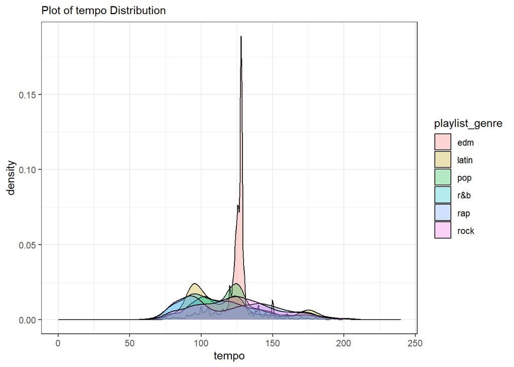

```r
#plotting the distribution of tempo of tracks
ggplot(spotify, aes(tempo, fill=playlist_genre)) +
  geom_density(alpha = 0.3) + theme_bw() +
  ggtitle("Plot of tempo Distribution") +
  theme(plot.title = element_text(size = 11))
```

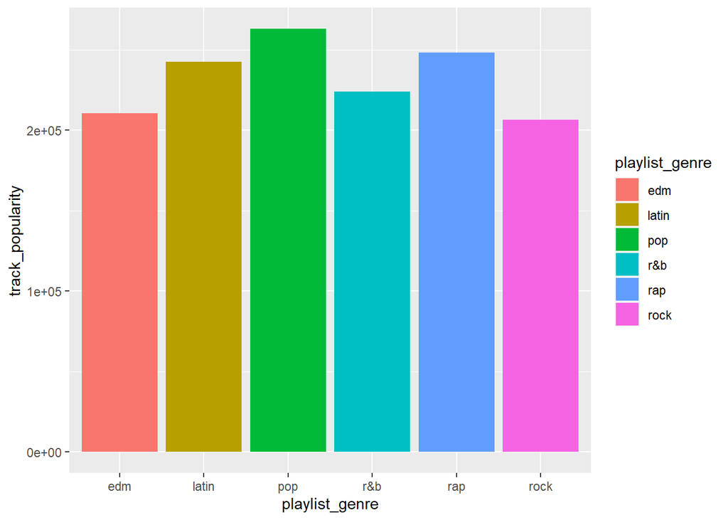

```r
#plotting the popularity of tracks according to genre
ggplot(spotify, aes(x=playlist_genre, y=track_popularity, fill=playlist_genre)) +
 geom_bar(stat="identity")
```